# 01_08B_ivospa_stock_Prophet

## Prophet 기본 이해

- 관련 코드 : https://facebook.github.io/prophet/docs/quick_start.html#python-api
- 데이터 출처 : https://github.com/facebook/prophet/blob/main/examples/example_wp_log_peyton_manning.csv
- 데이터 분석 코드
  - [github 코드](https://github.com/LDJWJ/dataAnalysis/blob/main/01_08B_ivospa_stock_Prophet.ipynb)
  - [HTML코드](https://ldjwj.github.io/dataAnalysis/01_08B_ivospa_stock_Prophet.html)

01. 라이브러리 불러오기 및 설치  
02. Prophet를 활용한 모델 만들기  
03. 예측 내용 그래프로 표시

### 01. 라이브러리 불러오기 및 설치

목차로 이동하기

### fbprophet 설치가 안되어 있을 경우,

- pip uninstall pystan
- pip install pystan==2.17.1.0
- pip install fbprophet

```python
# 라이브러리 불러오기
import pandas as pd
from fbprophet import Prophet
```

```python
# 예제 데이터 셋을 활용
df = pd.read_csv('./data/Prophet/example_wp_log_peyton_manning.csv')
print(df.shape)
df.head()
```

```
(2905, 2)
```

|  | ds | y |
| --- | --- | --- |
| 0 | 2007-12-10 | 9.590761 |
| 1 | 2007-12-11 | 8.519590 |
| 2 | 2007-12-12 | 8.183677 |
| 3 | 2007-12-13 | 8.072467 |
| 4 | 2007-12-14 | 7.893572 |

### 02. Prophet를 활용한 모델 만들기

목차로 이동하기

- Prophet는 Facebook에서 만든 시계열 데이터 모델링을 위한 파이썬 모듈
- URL : https://facebook.github.io/prophet/
- Prophet은 머신러닝 기법은 아니며, ARIMA라고 하는 알고리즘 방법론을 응용.
- Prophet는 한층 더 진보적인 방법으로 트렌드와 주기적 특성 뿐 아니라 예외적이고 이벤트와 같은 휴가철 상황까지도 모델링하도록 ARIMA알고리즘을 확장한 것.
- Prophet 객체 생성
- fit() 메소드를 이용한 최적화(학습)을 수행

```python
m = Prophet()
m.fit(df)
```

```
INFO:fbprophet:Disabling daily seasonality. Run prophet with daily_seasonality=True to override this.
```

```
<fbprophet.forecaster.Prophet at 0x7feed3fc0280>
```

```python
future = m.make_future_dataframe(periods=365)
print(df.shape)
print(future.shape)
future.tail()
```

```
(2905, 2)
(3270, 1)
```

|  | ds |
| --- | --- |
| 3265 | 2017-01-15 |
| 3266 | 2017-01-16 |
| 3267 | 2017-01-17 |
| 3268 | 2017-01-18 |
| 3269 | 2017-01-19 |

- ds의 열이 있는 데이터 프레임에서 예측이 이루어집니다. make_future_dataframe를 사용하여 지정된 일수만큼 미래로 확장되는 적절한 데이터 프레임을 얻을 수 있음.

### 예측하기

- predict() 메소드는 yhat이라는 이름의 예측 값을 각 행에 할당.
- 여기서 예측 개체는 예측이 포함된 열과 구성 요소 및 불확실성 간격에 대한 열을 포함하는 새 데이터 프레임입니다.

```python
forecast = m.predict(future)
print(forecast.shape)
forecast[['ds', 'yhat', 'yhat_lower', 'yhat_upper']].tail()
```

```
(3270, 19)
```

|  | ds | yhat | yhat_lower | yhat_upper |
| --- | --- | --- | --- | --- |
| 3265 | 2017-01-15 | 8.214006 | 7.512405 | 8.975372 |
| 3266 | 2017-01-16 | 8.539078 | 7.746396 | 9.279901 |
| 3267 | 2017-01-17 | 8.326518 | 7.587072 | 9.078349 |
| 3268 | 2017-01-18 | 8.159179 | 7.465441 | 8.866700 |
| 3269 | 2017-01-19 | 8.171119 | 7.448082 | 8.900605 |

### 03. 예측 내용 그래프로 표시

목차로 이동하기

### Prophet.plot

- Prophet.plot이라고 불리는 것으로 예측에 대한 plot를 그릴 수 있다.

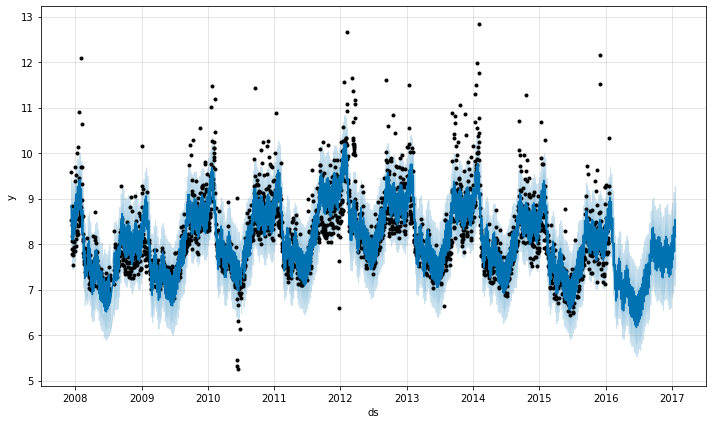

```python
fig1 = m.plot(forecast)
```

### Prophet.plot_components 메소드로 세부 예측 요소 확인

- 미래 예측 요소 확인
  - trend, yearly seasonality에 대한 시계열 데이터
  - weekly seasonality에 대한 시계열 데이터

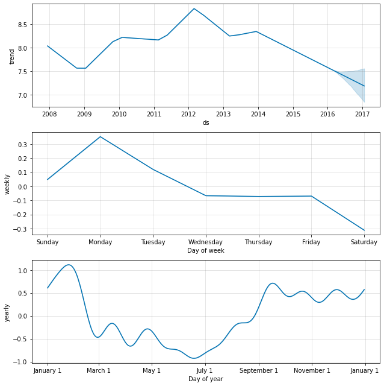

```python
fig2 = m.plot_components(forecast)
```

### plotly를 활용한 미래 예측 내용 만들기

```python
from fbprophet.plot import plot_plotly, plot_components_plotly

plot_plotly(m, forecast)
```

[interactive chart not shown]

```python
plot_components_plotly(m, forecast)
```

[interactive chart not shown]